# EDS 230/ESM 232 Growth Model Assignment

Genevieve Chiong, Halina Do-Linh, Mia Forsline

2022-05-19

# Introduction

Consider the following model of forest growth (where forest size in measured in units of carbon (C)):

- dC/dt = r ∗ C for forests
  - where C is below a threshold canopy closure
  - and *r* is the early exponential growth rate
- dC/dt = g ∗ (1−C/K) for forests
  - where C is at or above the threshold canopy closure
  - and *g* is the linear growth rate
- and *K* is a carrying capacity in units of carbon.

The size of the forest (C), canopy closure threshold, and carrying capacity (K) are all in units of carbon.

You could think of the canopy closure threshold as the size of the forest at which growth rates change from exponential to linear.

You can think of *r*, as early exponential growth rate and *g* as the linear growth rate once canopy closure has been reached

# 1. Implement this model in R (as a differential equation)

```r
source(here("R", "forest_growth.R"))
source(here("R", "compute_metrics.R"))

forest_growth
```

```
## function (time, C, parms)
## {
##     if (C < parms$threshold) {
##         dC_dt = parms$r * C
##     }
##     else {
##         dC_dt = parms$g * (1 - (C/parms$K))
##     }
##     return(list(dC_dt))
## }
```

```r
compute_metrics
```

```
## function (result)
## {
##     maxpop = max(result$P)
##     idx = which.max(result$P)
##     meanpop = mean(result$P)
##     return(list(maxpop = maxpop, meanpop = meanpop))
## }
```

# 2. Run the model for 300 years (using the ODE solver) starting with an initial forest size of 10 kg/C, and using the following parameters:

- canopy closure threshold of 50 kgC
- *K* = 250 kg C (carrying capacity)
- *r* = 0.01 (exponential growth rate before before canopy closure)
- *g* = 2 kg/year (linear growth rate after canopy closure)

```r
#set up parameters
C = 10 #forest size
time = seq(from = 1, to = 300) #run the model for 300 years
threshold = 50 #canopy closure
K = 250
r = 0.01 #exponential growth rate
g = 2 #linear growth rate

#create parameters list
parms = list(time = time,
             threshold = threshold,
             K = K,
             r = r,
             g = g)

#apply solver - we input the differential equation and the ODE solver integrates it
results = ode(C, time, forest_growth, parms)

head(results)
```

```
##      time        1
## [1,]    1 10.00000
## [2,]    2 10.10050
## [3,]    3 10.20202
## [4,]    4 10.30455
## [5,]    5 10.40811
## [6,]    6 10.51271
```

```r
# add more meaningful names
colnames(results) = c("year","P")
```

## Graph the results.

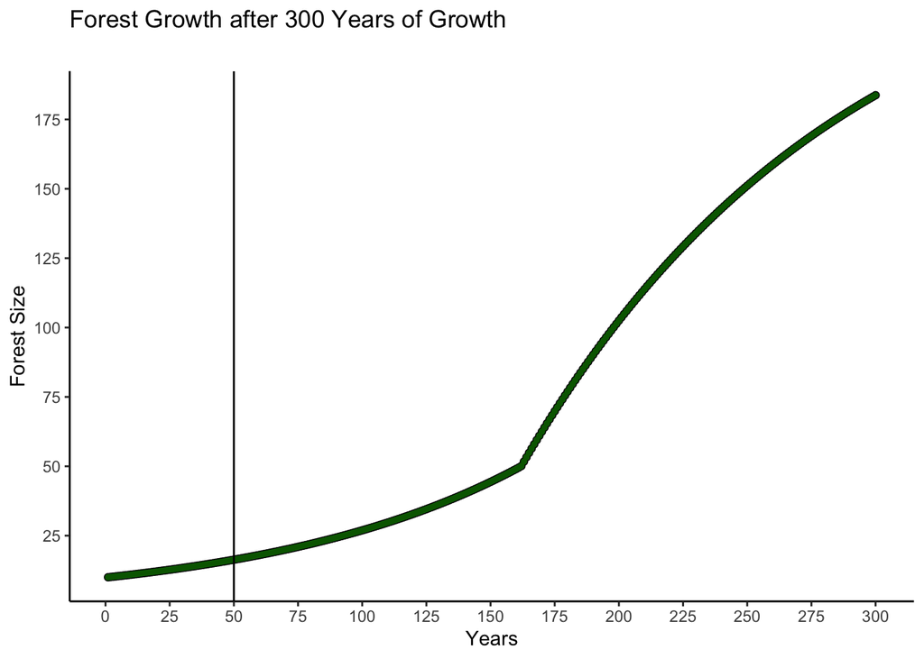

```r
ggplot(as.data.frame(results), aes(year, P)) +
  geom_point() +
  labs(y="Forest Population",
       x = "Years") +
  theme_classic() +
geom_point(col = "darkgreen",
             size = 1) +
  ggtitle(label = "Forest Growth after 300 Years of Growth",
          subtitle = "") +
  labs(y ="Forest Size",
       x = "Years") +
  geom_vline(xintercept = 50) +
  theme_classic() +
  scale_x_continuous(breaks = seq(0, 300, by = 25)) +
  scale_y_continuous(breaks = seq(0, 200, by = 25))
```

# 3. Run a sobol sensitivity analysis that explores how the estimated maximum and mean forest size (e.g maximum and mean values of C over the 300 years) varies with the pre canopy closure growth rate (*r*) and post-canopy closure growth rate (*g*) and canopy closure threshold and carrying capacity(*K*)

Assume that parameters are all normally distributed with means as given above and standard deviation of 10% of mean value.

```r
#set parameters
C = 10 #forest size

#number of samples
np = 100

#create first sample parameters from normal distributions
r = rnorm(mean = 0.01, sd = r*.10, n = np)
g = rnorm(mean = 2, sd = g*.10, n = np)
threshold = rnorm(mean = 50, sd = threshold*.10, n = np)
K = rnorm(mean = 250, sd = K*.10, n = np)

#create the first dataframe
X1 = cbind.data.frame(r = r, g = g, threshold = threshold, K = K)

#create second sample parameters from normal distributions (this is just how sobol works)
r = rnorm(mean = 0.01, sd = r*.10, n = np)
g = rnorm(mean = 2, sd = g*.10, n = np)
threshold = rnorm(mean = 50, sd = threshold*.10, n = np)
K = rnorm(mean = 250, sd = K*.10, n = np)

#create the second dataframe
X2 = cbind.data.frame(r = r, g = g, threshold = threshold, K = K)
```

```r
#create our sobel object and get sets of parameters for running the model
sens_P = sobolSalt(model = NULL, X1, X2, nboot = 300)

colnames(sens_P$X) = c("r",
                       "g",
                       "threshold",
                       "K")

#our parameter sets are
head(sens_P$X)
```

```
##                r        g threshold        K
## [1,] 0.009737831 2.069509  46.21118 227.9340
## [2,] 0.010152194 2.551949  48.18934 289.0644
## [3,] 0.009977065 2.045054  50.14091 228.6748
## [4,] 0.009238864 1.884754  49.30767 226.6354
## [5,] 0.009750596 2.354355  55.60882 215.3142
## [6,] 0.010904537 1.679705  47.75746 232.1519
```

```r
# define a wrapper function to do everything we need - run solver and compute metrics - and send back results for each parameter

p_wrapper = function(r, g, threshold, K, Pinitial, simtimes, func) {
    parms = list(r = r,
                 g = g,
                 threshold = threshold,
                 K = K)
    result = ode(y = Pinitial,
                 times = simtimes,
                 func = func,
                 parms = parms)
    colnames(result) = c("time","P")
  # get metrics
  metrics = compute_metrics(as.data.frame(result))
  return(metrics)
}
```

```r
# reiterate parameters
Pinitial = 10 #forest size (initial population in units of kg C)
simtimes = seq(from = 1, to = 300) #run the model for 300 years
func = forest_growth

# now use pmap as we did before
allresults = as.data.frame(sens_P$X) %>%
  pmap(p_wrapper,
       Pinitial = Pinitial,
       simtimes = simtimes,
       func = func)
```

```r
# extract out results from pmap into a data frame
allres = allresults %>% map_dfr(`[`,c("maxpop","meanpop"))
```